```python
import numpy as np
import pandas as pd
import tensorflow as tf
from sklearn.metrics import log_loss, confusion_matrix, classification_report, f1_score
import joblib
from tqdm import tqdm
from sklearn.pipeline import Pipeline
```

```python
from glob import glob

bad_images = glob('/kaggle/input/mack-rel/mackerel/test/bad/*.jpg')
good_images = glob('/kaggle/input/mack-rel/mackerel/test/good/*.jpg')
```

# Load Test data sets of size 1000 samples (500 in each class)

```python
labels1 = np.load('/kaggle/input/test-set-samples-1000-mackerel/labels1.npy')
labels2 = np.load('/kaggle/input/test-set-samples-1000-mackerel/labels2.npy')
labels3 = np.load('/kaggle/input/test-set-samples-1000-mackerel/labels3.npy')
labels4 = np.load('/kaggle/input/test-set-samples-1000-mackerel/labels4.npy')
test_1 = np.load('/kaggle/input/test-set-samples-1000-mackerel/test1.npy')
test_2 = np.load('/kaggle/input/test-set-samples-1000-mackerel/test2.npy')
test_3 = np.load('/kaggle/input/test-set-samples-1000-mackerel/test3.npy')
test_4 = np.load('/kaggle/input/test-set-samples-1000-mackerel/test4.npy')
print('Data Loaded Successfully!!!')
```

```
Data Loaded Successfully!!!
```

# Load best models

```python
svc_99pca_path = '/kaggle/input/ml-models-trained-mackerel/SVC_PCA_99_pipeline.joblib'
catboost_path = '/kaggle/input/ml-models-trained-mackerel/CatBoost.joblib'
xgb_path = '/kaggle/input/ml-models-trained-mackerel/XGBoost.joblib'
lda_path = '/kaggle/input/ml-models-trained-mackerel/LDA.joblib'
lightgbm_path = '/kaggle/input/ml-models-trained-mackerel/LightGBM.joblib'
rfc_path = '/kaggle/input/ml-models-trained-mackerel/RandomForest.joblib'
```

```python
svc_model = joblib.load(svc_99pca_path)
catboost_model = joblib.load(catboost_path)
xgb_model = joblib.load(xgb_path)
lda_model = joblib.load(lda_path)
lightgbm_model = joblib.load(lightgbm_path)
rfc_model = joblib.load(rfc_path)

print("SVC Model loaded:", svc_model)
print("CatBoost Model loaded:", catboost_model)
print("XGBoost Model loaded:", xgb_model)
print("LDA Model loaded:", lda_model)
print("LightGBM Model loaded:", lightgbm_model)
print("Random Forest Model loaded:", rfc_model)
```

```
SVC Model loaded: Pipeline(steps=[('reduction', PCA(n_components=0.99, svd_solver='full')),
                ('model', SVC(probability=True))])
CatBoost Model loaded: <catboost.core.CatBoostClassifier object at 0x7c23f6588130>
XGBoost Model loaded: XGBClassifier(base_score=None, booster=None, callbacks=None,
              colsample_bylevel=None, colsample_bynode=None,
              colsample_bytree=None, device=None, early_stopping_rounds=None,
              enable_categorical=False, eval_metric='logloss',
              feature_types=None, gamma=None, grow_policy=None,
              importance_type=None, interaction_constraints=None,
              learning_rate=None, max_bin=None, max_cat_threshold=None,
              max_cat_to_onehot=None, max_delta_step=None, max_depth=None,
              max_leaves=None, min_child_weight=None, missing=nan,
              monotone_constraints=None, multi_strategy=None, n_estimators=None,
              n_jobs=None, num_parallel_tree=None, random_state=None, ...)
LDA Model loaded: LinearDiscriminantAnalysis()
LightGBM Model loaded: LGBMClassifier()
Random Forest Model loaded: RandomForestClassifier()
```

# MODEL EVALUATION

```python
import numpy as np
import joblib
import matplotlib.pyplot as plt
import seaborn as sns
from sklearn.metrics import (
    confusion_matrix,
    classification_report,
    roc_auc_score,
    f1_score,
    precision_score,
    recall_score,
    log_loss
)
import time  # Import the time module

def evaluate_model(model, test_sets, true_labels_list, threshold=0.5):
    plt.figure(figsize=(12, 10))

    # Initialize lists to store metrics for averaging later
    roc_auc_list = []
    f1_list = []
    precision_list = []
    recall_list = []
    log_loss_list = []
    prediction_times = []  # List to store prediction times

    for i, (test_data, true_labels) in enumerate(zip(test_sets, true_labels_list)):
        # Start time for predictions
        start_time = time.time()

        # Predict probabilities on the test data
        probabilities = model.predict_proba(test_data)[:, 1]  # Get probabilities of the positive class
        predictions = (probabilities >= threshold).astype(int)  # Convert probabilities to binary predictions

        # End time for predictions
        end_time = time.time()
        prediction_time = end_time - start_time
        prediction_times.append(prediction_time)  # Store the prediction time

        # Calculate metrics
        roc_auc = roc_auc_score(true_labels, probabilities)
        f1 = f1_score(true_labels, predictions, average='weighted')
        precision = precision_score(true_labels, predictions, average='weighted')
        recall = recall_score(true_labels, predictions, average='weighted')
        log_loss_value = log_loss(true_labels, probabilities)

        # Store metrics for averaging
        roc_auc_list.append(roc_auc)
        f1_list.append(f1)
        precision_list.append(precision)
        recall_list.append(recall)
        log_loss_list.append(log_loss_value)

        # Print metrics for each test set
        print(f"Results for test set {i + 1}:")
        print(f"Prediction Time: {prediction_time:.4f} seconds")
        print(f"ROC AUC Score: {roc_auc:.4f}")
        print(f"F1 Score: {f1:.4f}")
        print(f"Precision: {precision:.4f}")
        print(f"Recall: {recall:.4f}")
        print(f"Log Loss: {log_loss_value:.4f}\n")

        # Confusion matrix
        cm = confusion_matrix(true_labels, predictions)

        # Classification report
        report = classification_report(true_labels, predictions)
        print("Classification Report:\n", report)

        # Plot confusion matrix
        plt.subplot(2, 2, i + 1)
        sns.heatmap(cm, annot=True, fmt='d', cmap='Blues')
        plt.title(f'Confusion Matrix for Test Set {i + 1}')
        plt.xlabel('Predicted Labels')
        plt.ylabel('True Labels')

    plt.tight_layout()
    plt.show()

    # Calculate and print average metrics
    print("Average Metrics Across All Test Sets:")
    print(f"Average ROC AUC Score: {np.mean(roc_auc_list):.4f}")
    print(f"Average F1 Score: {np.mean(f1_list):.4f}")
    print(f"Average Precision: {np.mean(precision_list):.4f}")
    print(f"Average Recall: {np.mean(recall_list):.4f}")
    print(f"Average Log Loss: {np.mean(log_loss_list):.4f}")
    print(f"Average Prediction Time: {np.mean(prediction_times):.4f} seconds")




test_sets = [test_1, test_2, test_3, test_4]
true_labels_list = [labels1, labels2, labels3, labels4]
```

# NOTE:

#### --> 0 is class "BAD" and 1 is class "GOOD"

#### --> Time taken : Inference time taken by model to predict on 1000 images (Feature extraction and Image preprocessing is not included only model prediction time)

# SVC with PCA

```
Results for test set 1:
Prediction Time: 4.2589 seconds
ROC AUC Score: 0.9253
F1 Score: 0.8376
Precision: 0.8417
Recall: 0.8380
Log Loss: 0.3597

Classification Report:
               precision    recall  f1-score   support

         0.0       0.88      0.79      0.83       500
         1.0       0.81      0.89      0.85       500

    accuracy                           0.84      1000
   macro avg       0.84      0.84      0.84      1000
weighted avg       0.84      0.84      0.84      1000

Results for test set 2:
Prediction Time: 4.2186 seconds
ROC AUC Score: 0.9453
F1 Score: 0.8626
Precision: 0.8674
Recall: 0.8630
Log Loss: 0.3223

Classification Report:
               precision    recall  f1-score   support

         0.0       0.91      0.81      0.86       500
         1.0       0.83      0.92      0.87       500

    accuracy                           0.86      1000
   macro avg       0.87      0.86      0.86      1000
weighted avg       0.87      0.86      0.86      1000

Results for test set 3:
Prediction Time: 4.2828 seconds
ROC AUC Score: 0.9442
F1 Score: 0.8698
```

[output cut: 16 more lines]

```
ROC AUC Score: 0.9388
F1 Score: 0.8507
Precision: 0.8534
Recall: 0.8510
Log Loss: 0.3286

Classification Report:
               precision    recall  f1-score   support

         0.0       0.88      0.81      0.84       500
         1.0       0.82      0.89      0.86       500

    accuracy                           0.85      1000
   macro avg       0.85      0.85      0.85      1000
weighted avg       0.85      0.85      0.85      1000
```

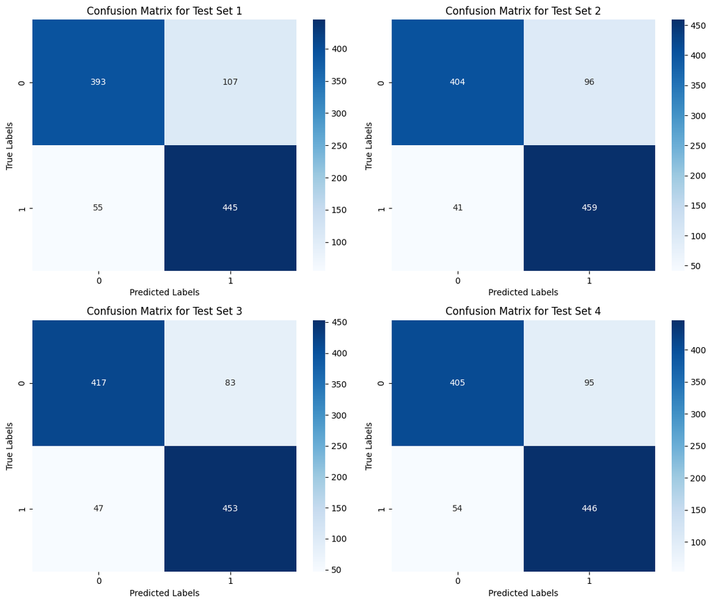

```
Average Metrics Across All Test Sets:
Average ROC AUC Score: 0.9384
Average F1 Score: 0.8552
Average Precision: 0.8586
Average Recall: 0.8555
Average Log Loss: 0.3319
Average Prediction Time: 4.3053 seconds
```

```python
evaluate_model(svc_model, test_sets, true_labels_list, threshold=0.5)
```

# LightGBM (Gradient booster)

```
Results for test set 1:
Prediction Time: 0.0226 seconds
ROC AUC Score: 0.9274
F1 Score: 0.8405
Precision: 0.8455
Recall: 0.8410
Log Loss: 0.3738

Classification Report:
               precision    recall  f1-score   support

         0.0       0.88      0.78      0.83       500
         1.0       0.81      0.90      0.85       500

    accuracy                           0.84      1000
   macro avg       0.85      0.84      0.84      1000
weighted avg       0.85      0.84      0.84      1000

Results for test set 2:
Prediction Time: 0.0257 seconds
ROC AUC Score: 0.9269
F1 Score: 0.8515
Precision: 0.8565
Recall: 0.8520
Log Loss: 0.3677

Classification Report:
               precision    recall  f1-score   support

         0.0       0.90      0.80      0.84       500
         1.0       0.82      0.91      0.86       500

    accuracy                           0.85      1000
   macro avg       0.86      0.85      0.85      1000
weighted avg       0.86      0.85      0.85      1000

Results for test set 3:
Prediction Time: 0.0187 seconds
ROC AUC Score: 0.9414
F1 Score: 0.8647
```

[output cut: 16 more lines]

```
ROC AUC Score: 0.9313
F1 Score: 0.8545
Precision: 0.8597
Recall: 0.8550
Log Loss: 0.3617

Classification Report:
               precision    recall  f1-score   support

         0.0       0.90      0.80      0.85       500
         1.0       0.82      0.91      0.86       500

    accuracy                           0.85      1000
   macro avg       0.86      0.85      0.85      1000
weighted avg       0.86      0.85      0.85      1000
```

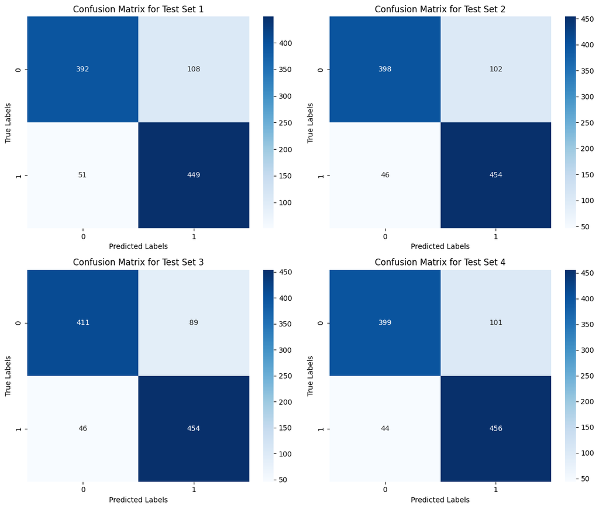

```
Average Metrics Across All Test Sets:
Average ROC AUC Score: 0.9317
Average F1 Score: 0.8528
Average Precision: 0.8573
Average Recall: 0.8532
Average Log Loss: 0.3616
Average Prediction Time: 0.0219 seconds
```

```python
evaluate_model(lightgbm_model, test_sets, true_labels_list, threshold=0.5)
```

# XGB (Gradient booster)

```
Results for test set 1:
Prediction Time: 0.0238 seconds
ROC AUC Score: 0.9193
F1 Score: 0.8336
Precision: 0.8374
Recall: 0.8340
Log Loss: 0.3869

Classification Report:
               precision    recall  f1-score   support

         0.0       0.87      0.78      0.83       500
         1.0       0.80      0.88      0.84       500

    accuracy                           0.83      1000
   macro avg       0.84      0.83      0.83      1000
weighted avg       0.84      0.83      0.83      1000

Results for test set 2:
Prediction Time: 0.0198 seconds
ROC AUC Score: 0.9267
F1 Score: 0.8445
Precision: 0.8495
Recall: 0.8450
Log Loss: 0.3662

Classification Report:
               precision    recall  f1-score   support

         0.0       0.89      0.79      0.84       500
         1.0       0.81      0.90      0.85       500

    accuracy                           0.84      1000
   macro avg       0.85      0.84      0.84      1000
weighted avg       0.85      0.84      0.84      1000

Results for test set 3:
Prediction Time: 0.0117 seconds
ROC AUC Score: 0.9321
F1 Score: 0.8376
```

[output cut: 16 more lines]

```
ROC AUC Score: 0.9290
F1 Score: 0.8435
Precision: 0.8484
Recall: 0.8440
Log Loss: 0.3617

Classification Report:
               precision    recall  f1-score   support

         0.0       0.89      0.79      0.83       500
         1.0       0.81      0.90      0.85       500

    accuracy                           0.84      1000
   macro avg       0.85      0.84      0.84      1000
weighted avg       0.85      0.84      0.84      1000
```

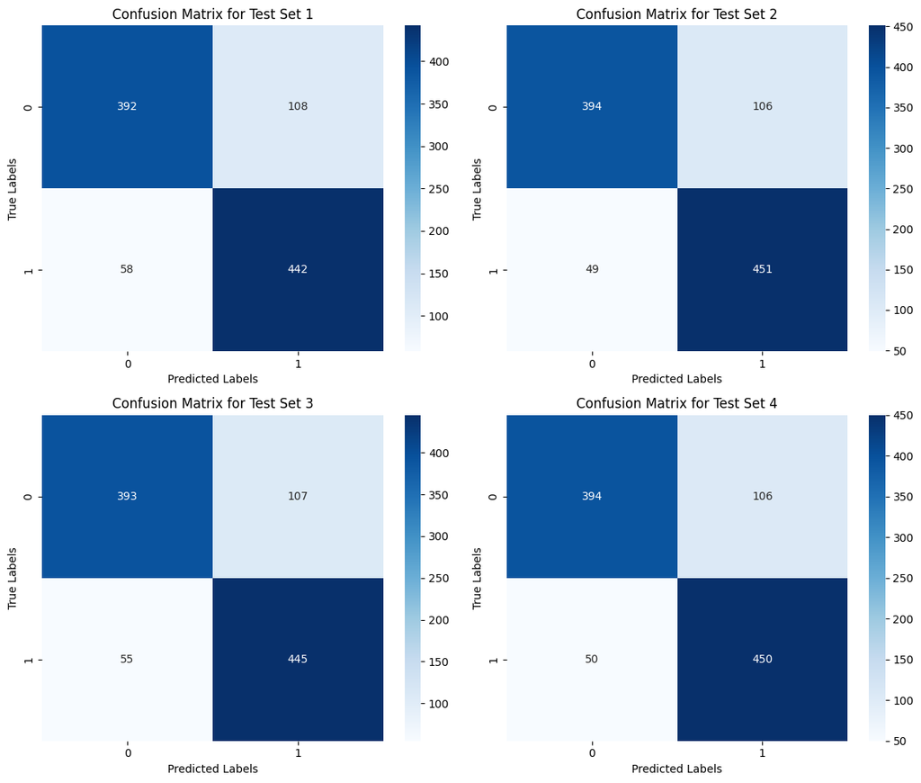

```
Average Metrics Across All Test Sets:
Average ROC AUC Score: 0.9268
Average F1 Score: 0.8398
Average Precision: 0.8442
Average Recall: 0.8402
Average Log Loss: 0.3664
Average Prediction Time: 0.0167 seconds
```

```python
evaluate_model(xgb_model, test_sets, true_labels_list, threshold=0.5)
```

# Random Forest Classifier

```
Results for test set 1:
Prediction Time: 0.0530 seconds
ROC AUC Score: 0.8989
F1 Score: 0.7999
Precision: 0.8151
Recall: 0.8020
Log Loss: 0.4911

Classification Report:
               precision    recall  f1-score   support

         0.0       0.88      0.70      0.78       500
         1.0       0.75      0.90      0.82       500

    accuracy                           0.80      1000
   macro avg       0.82      0.80      0.80      1000
weighted avg       0.82      0.80      0.80      1000

Results for test set 2:
Prediction Time: 0.0477 seconds
ROC AUC Score: 0.8963
F1 Score: 0.7769
Precision: 0.7965
Recall: 0.7800
Log Loss: 0.4925

Classification Report:
               precision    recall  f1-score   support

         0.0       0.87      0.66      0.75       500
         1.0       0.73      0.90      0.80       500

    accuracy                           0.78      1000
   macro avg       0.80      0.78      0.78      1000
weighted avg       0.80      0.78      0.78      1000

Results for test set 3:
Prediction Time: 0.0453 seconds
ROC AUC Score: 0.9279
F1 Score: 0.8198
```

[output cut: 16 more lines]

```
ROC AUC Score: 0.8990
F1 Score: 0.7900
Precision: 0.8106
Recall: 0.7930
Log Loss: 0.4876

Classification Report:
               precision    recall  f1-score   support

         0.0       0.88      0.67      0.77       500
         1.0       0.74      0.91      0.82       500

    accuracy                           0.79      1000
   macro avg       0.81      0.79      0.79      1000
weighted avg       0.81      0.79      0.79      1000
```

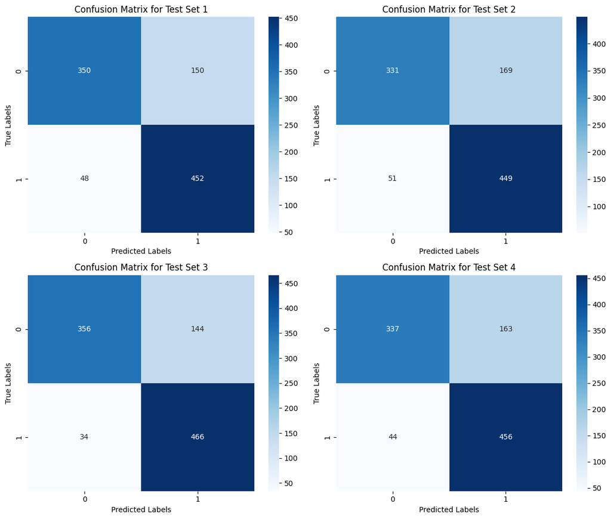

```
Average Metrics Across All Test Sets:
Average ROC AUC Score: 0.9055
Average F1 Score: 0.7967
Average Precision: 0.8151
Average Recall: 0.7993
Average Log Loss: 0.4846
Average Prediction Time: 0.0491 seconds
```

```python
evaluate_model(rfc_model, test_sets, true_labels_list, threshold=0.5)
```

# LDA (Linear Discriminant Analysis)

```
Results for test set 1:
Prediction Time: 0.0078 seconds
ROC AUC Score: 0.9048
F1 Score: 0.8219
Precision: 0.8230
Recall: 0.8220
Log Loss: 0.4067

Classification Report:
               precision    recall  f1-score   support

         0.0       0.84      0.79      0.82       500
         1.0       0.80      0.85      0.83       500

    accuracy                           0.82      1000
   macro avg       0.82      0.82      0.82      1000
weighted avg       0.82      0.82      0.82      1000

Results for test set 2:
Prediction Time: 0.0018 seconds
ROC AUC Score: 0.9293
F1 Score: 0.8418
Precision: 0.8438
Recall: 0.8420
Log Loss: 0.3457

Classification Report:
               precision    recall  f1-score   support

         0.0       0.87      0.81      0.84       500
         1.0       0.82      0.88      0.85       500

    accuracy                           0.84      1000
   macro avg       0.84      0.84      0.84      1000
weighted avg       0.84      0.84      0.84      1000

Results for test set 3:
Prediction Time: 0.0012 seconds
ROC AUC Score: 0.9252
F1 Score: 0.8298
```

[output cut: 16 more lines]

```
ROC AUC Score: 0.9280
F1 Score: 0.8370
Precision: 0.8372
Recall: 0.8370
Log Loss: 0.3467

Classification Report:
               precision    recall  f1-score   support

         0.0       0.85      0.82      0.83       500
         1.0       0.83      0.85      0.84       500

    accuracy                           0.84      1000
   macro avg       0.84      0.84      0.84      1000
weighted avg       0.84      0.84      0.84      1000
```

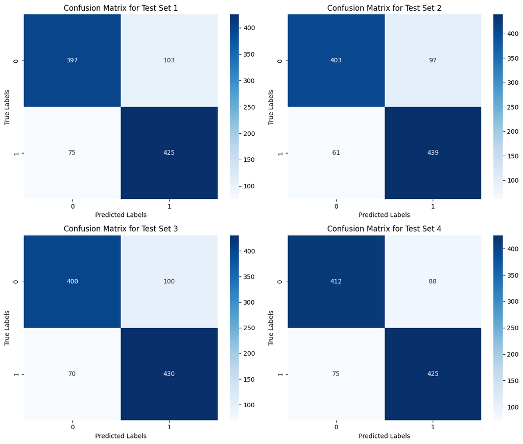

```
Average Metrics Across All Test Sets:
Average ROC AUC Score: 0.9218
Average F1 Score: 0.8326
Average Precision: 0.8338
Average Recall: 0.8327
Average Log Loss: 0.3635
Average Prediction Time: 0.0030 seconds
```

```python
evaluate_model(lda_model, test_sets, true_labels_list, threshold=0.5)
```

# CatBoost (Gradient booster)

```
Results for test set 1:
Prediction Time: 0.0848 seconds
ROC AUC Score: 0.9270
F1 Score: 0.8466
Precision: 0.8504
Recall: 0.8470
Log Loss: 0.3706

Classification Report:
               precision    recall  f1-score   support

         0.0       0.88      0.80      0.84       500
         1.0       0.82      0.90      0.85       500

    accuracy                           0.85      1000
   macro avg       0.85      0.85      0.85      1000
weighted avg       0.85      0.85      0.85      1000
```

```
TBB Warning: The number of workers is currently limited to 0. The request for 3 workers is ignored. Further requests for more workers will be silently ignored until the limit changes.
```

```
Results for test set 2:
Prediction Time: 0.0471 seconds
ROC AUC Score: 0.9301
F1 Score: 0.8517
Precision: 0.8553
Recall: 0.8520
Log Loss: 0.3627

Classification Report:
               precision    recall  f1-score   support

         0.0       0.89      0.80      0.84       500
         1.0       0.82      0.90      0.86       500

    accuracy                           0.85      1000
   macro avg       0.86      0.85      0.85      1000
weighted avg       0.86      0.85      0.85      1000

Results for test set 3:
Prediction Time: 0.0496 seconds
ROC AUC Score: 0.9456
F1 Score: 0.8718
Precision: 0.8746
Recall: 0.8720
Log Loss: 0.3351

Classification Report:
               precision    recall  f1-score   support

         0.0       0.91      0.83      0.87       500
         1.0       0.84      0.91      0.88       500

    accuracy                           0.87      1000
   macro avg       0.87      0.87      0.87      1000
weighted avg       0.87      0.87      0.87      1000

Results for test set 4:
Prediction Time: 0.0468 seconds
ROC AUC Score: 0.9338
F1 Score: 0.8577
Precision: 0.8613
Recall: 0.8580
Log Loss: 0.3541

Classification Report:
               precision    recall  f1-score   support

         0.0       0.90      0.81      0.85       500
         1.0       0.83      0.91      0.86       500

    accuracy                           0.86      1000
   macro avg       0.86      0.86      0.86      1000
weighted avg       0.86      0.86      0.86      1000
```

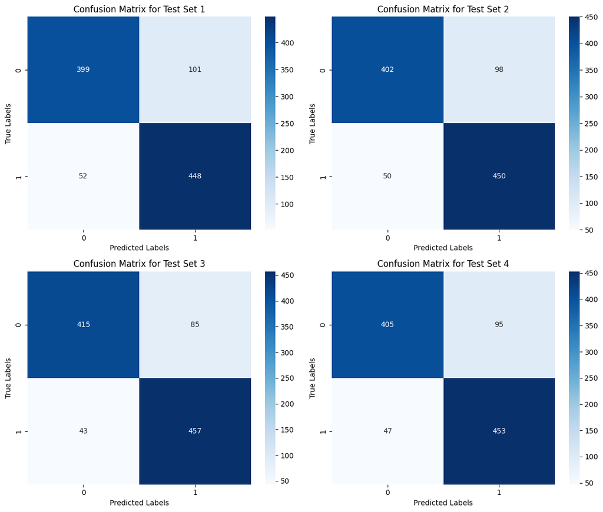

```
Average Metrics Across All Test Sets:
Average ROC AUC Score: 0.9341
Average F1 Score: 0.8569
Average Precision: 0.8604
Average Recall: 0.8572
Average Log Loss: 0.3556
Average Prediction Time: 0.0571 seconds
```

```python
evaluate_model(catboost_model, test_sets, true_labels_list, threshold=0.5)
```

# SPEED TEST FOR IMAGE PRE-PROCESSING and FEATURE EXTRACTION

```python
import numpy as np
import tensorflow as tf
from tensorflow.keras.applications import DenseNet121
from tensorflow.keras.models import Model
from tensorflow.keras.layers import GlobalAveragePooling2D
from PIL import Image
import cv2
import time
import random

def build_densenet_feature_extractor(input_shape=(224, 224, 3)):
    base_model = DenseNet121(weights='imagenet', include_top=False, input_shape=input_shape)
    x = GlobalAveragePooling2D()(base_model.output)
    model = Model(inputs=base_model.input, outputs=x)
    return model
model = build_densenet_feature_extractor()

def preprocess(img_path):
    img = Image.open(img_path)
    img = np.array(img)
    img = cv2.resize(img, (224, 224))
    img = tf.keras.applications.densenet.preprocess_input(img)
    img = np.expand_dims(img, axis=0)
    return img

def feature_extraction(img_path):
    img = preprocess(img_path)
    features = model.predict(img, verbose=False)
    return features

def evaluate_feature_extraction_times(image_paths, num_iterations=10):
    preprocessing_times = []
    feature_extraction_times = []
    combined_times = []

    for _ in tqdm(range(num_iterations)):
        for img_path in random.sample(good_images,1):
            # Time preprocessing
            start_time = time.time()
            img = preprocess(img_path)
            end_time = time.time()
            preprocessing_times.append(end_time - start_time)

            # Time feature extraction
            start_time = time.time()
            features = model.predict(img, verbose=False)
            end_time = time.time()
            feature_extraction_times.append(end_time - start_time)

            # Time combined process
            start_time = time.time()
            features_combined = feature_extraction(img_path)
            end_time = time.time()
            combined_times.append(end_time - start_time)

    avg_preprocessing_time = np.mean(preprocessing_times)
    avg_feature_extraction_time = np.mean(feature_extraction_times)
    avg_combined_time = np.mean(combined_times)

    print(f"Average Time for Preprocessing: {avg_preprocessing_time:.4f} seconds")
    print(f"Average Time for Feature Extraction: {avg_feature_extraction_time:.4f} seconds")
    print(f"Average Time for Combined Process: {avg_combined_time:.4f} seconds")
```

```
Downloading data from https://storage.googleapis.com/tensorflow/keras-applications/densenet/densenet121_weights_tf_dim_ordering_tf_kernels_notop.h5
29084464/29084464 ━━━━━━━━━━━━━━━━━━━━ 1s 0us/step
```

# Warm-up speed test (Downloads required model weights for feature extraction)

```python
evaluate_feature_extraction_times(good_images, num_iterations=1)
```

```
Average Time for Preprocessing: 0.0332 seconds
Average Time for Feature Extraction: 4.8555 seconds
Average Time for Combined Process: 0.2154 seconds
```

# Actual Speed test

```python
evaluate_feature_extraction_times(good_images, num_iterations=10)
```

```
Average Time for Preprocessing: 0.0151 seconds
Average Time for Feature Extraction: 0.2141 seconds
Average Time for Combined Process: 0.2169 seconds
```

# OBSERVATION:

- These 3 models **SVC with PCA**, **LightGBM** and **CATBOOST** are top performing models with average accuracies of **85.5% for SVC**, **85.3% for LightGBM** and **85.7% for CATBOOST**
- But **SVC is SLOWEST** among the models with **4.3 Sec** for prediction of **1000 images**. And **CATBOOST** took only **0.057 Sec** for And **LightGBM** took **0.02 Sec** only.
- The fastest model is **LDA** with speed **0.003 Sec** and **Accuracy 83.26%**

# CONCLUSION

- **CATBOOST** and **LightGBM** are two best choices to consider which offers good speeds and very good accuracies. **CATBOOST is slightly slower but more accurate** where as **LightGBM is slightly faster but less accurate**.
- I would suggest **CATBOOST** is best, since these speeds were for 1000 images. **For a single image it will be in Micro seconds (1e-6)**, which is almost negligible and kind of similar for both models. In that case **CATBOOST is clearly better than LightGBM**